# R Notebook

## Introduction

Science generally uses math to cope with different problems. Thus, it is assumed that students’ science scores are positively related with their math scores. Furthermore, male students are recognized as being stronger in spatial skills than female ones. Therefore, it could be hypothesized that male students’ science score is higher when they have same math score with female students.

This study aims to examine the relationships between math scores and science scores of high school seniors. Furthermore, whether the relationship is moderated by gender is further explored.

## Graphs and Descriptive Statistics

```r
library(tidyverse)
hsb2 <- read.csv("hsb2.csv")

# First, set Moderator as factor
gender <- factor(hsb2$female,
                 levels = c("0", "1"),
                 labels = c("male", "female"))
count(hsb2, gender == "male")
```

| gender == "male" | n |
| --- | --- |
| FALSE | 109 |
| TRUE | 91 |

There are 91 male students and 109 female students.

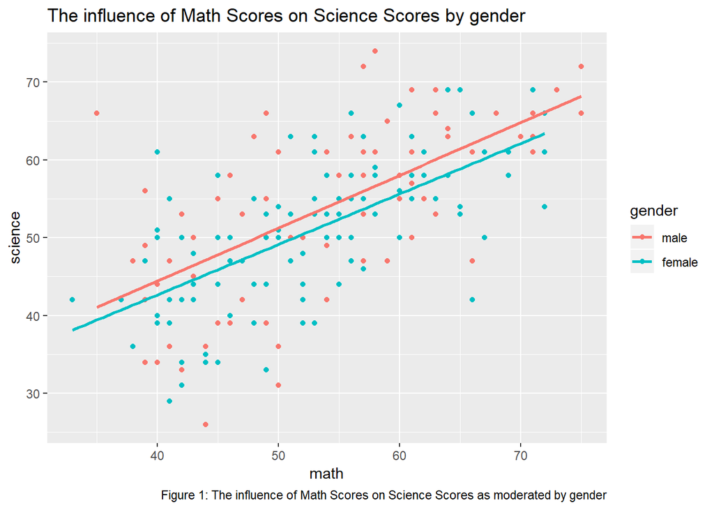

```r
# Second, take a look at the graphs to have a breif idea about
# interactions and relationships
ggplot(subset(hsb2, gender == "male"| gender == "female"),
       aes(x = math, y = science, color = gender)) +
  geom_point() +
  stat_smooth(method = "lm", se = FALSE) +
  labs(title = "The influence of Math Scores on Science Scores by gender ",
       caption = "Figure 1: The influence of Math Scores on Science Scores as moderated by gender")
```

Figure 1: The influence of Math Scores on Science Scores as moderated by gender.

```r
# Third, model interactions (IV & moderator) and DV
Scimg <- lm(science ~ math + gender + math*gender, data = hsb2)
summary(Scimg)
```

```
##
## Call:
## lm(formula = science ~ math + gender + math * gender, data = hsb2)
##
## Residuals:
##      Min       1Q   Median       3Q      Max
## -21.1539  -4.4966   0.1748   4.4627  24.9603
##
## Coefficients:
##                   Estimate Std. Error t value Pr(>|t|)
## (Intercept)       17.26226    4.49735   3.838 0.000167 ***
## math               0.67936    0.08358   8.128 4.83e-14 ***
## genderfemale      -0.52524    6.21204  -0.085 0.932704
## math:genderfemale -0.03119    0.11610  -0.269 0.788467
## ---
## Signif. codes:  0 '***' 0.001 '**' 0.01 '*' 0.05 '.' 0.1 ' ' 1
##
## Residual standard error: 7.663 on 196 degrees of freedom
## Multiple R-squared:   0.41,  Adjusted R-squared:  0.401
## F-statistic:  45.4 on 3 and 196 DF,  p-value: < 2.2e-16
```

```r
confint(Scimg, 'math', level=0.95)
```

```
##          2.5 %    97.5 %
## math 0.5145282 0.8441825
```

```r
confint(Scimg, 'genderfemale', level=0.95)
```

```
##                  2.5 %   97.5 %
## genderfemale -12.77626 11.72578
```

```r
confint(Scimg, 'math:genderfemale', level=0.95)
```

```
##                        2.5 %   97.5 %
## math:genderfemale -0.2601489 0.197766
```

## Conclusion

Multiple linear regression is conducted to test the relationship and moderation effect. Results shows that math score has positive relationship with science score. However, gender does not moderate the relationships between students’ math score and their science score.

The regression formula is as follow: Science score = 0.68*math – 0.53*gender – 0.03*math* gender + 17.26 We can conclude that with every point increase in math score, the students’ science score increases by 0.68 points.

> **I would like to thank you for your lectures. I really learned a lot from this course. Can’t imagine I never used R four months agao and now I rely on it so much. This course is a really good start for me. Now I’m confident in doing research analysis by independet studies. I really appreciate your help, Dr. Seaman!**